# Homework 1

# Question 3

Run ICA on the Iris dataset. Plot the independent components as a heatmap.

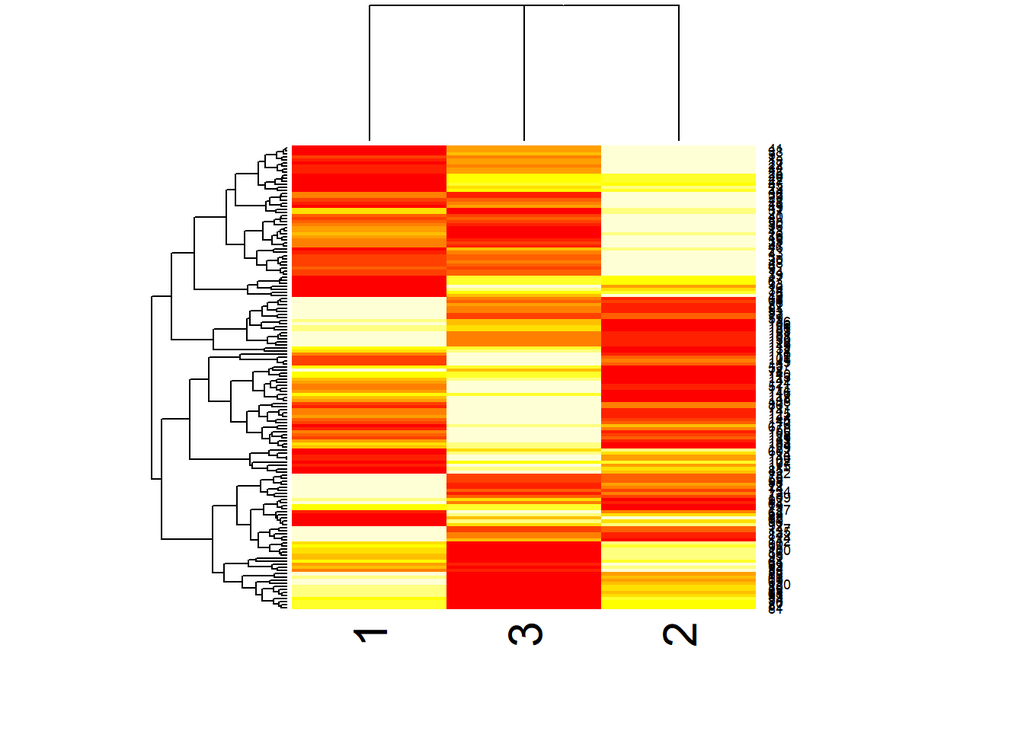

```r
iris_ica <- fastICA(iris_Data, 3, alg.typ = "parallel", fun = "logcosh", alpha = 1,
             method = "R", row.norm = FALSE, maxit = 200,
             tol = 0.0001, verbose = FALSE) #ICA on iris dataset, using fastICA

heatmap(iris_ica$S) #ICA heatmap
```

# Question 4

Use Kmeans to cluster the Iris data.

- Use the silhouette function in the cluster package to find the optimal number of clusters for kmeans for the iris dataset. Then cluster using kmeans clustering. Does the data cluster by species?
- Using this clustering, color the PCA plot according to the clusters.

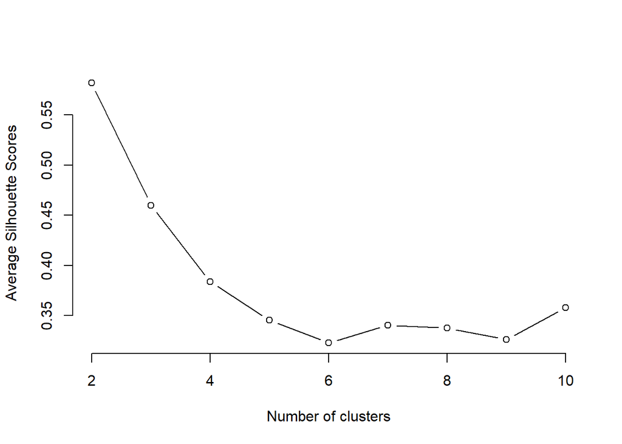

```r
sil_score <- function(k){ #Silhouette function
  km <- kmeans(iris_scaled, centers = k, nstart=25)
  ss <- silhouette(km$cluster, dist(iris_scaled))
  mean(ss[, 3])
}
k <- 2:10
avg_sil <- sapply(k, sil_score)
plot(k, type='b', avg_sil, xlab='Number of clusters', ylab='Average Silhouette Scores', frame=FALSE)
```

The silhouette function shows that the optimal number of clusters for doing kmeans is 2, which does not correlate with the number of species we have, which we know is 3.

```r
iris_km <- kmeans(iris_scaled, 2) #Utilizing kmeans function to run kmeans on iris data with 2 centers as suggested by silhouette plot.
```

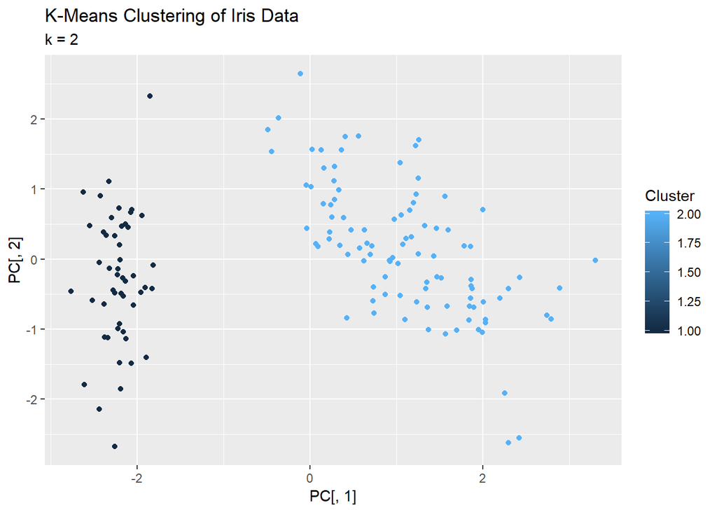

```r
ggplot(iris_km, aes(PC[,1], PC[,2], color = iris_km$cluster)) + geom_point() + labs(title = "K-Means Clustering of Iris Data", subtitle = "k = 2", color = "Cluster") #Plotting K-means
```

# Question 5

Use hierarchical clustering to cluster the Iris data.

- Try two different linkage types, and two different distance metrics.
- For one linkage type and one distance metric, try two different cut points.
- Using this clustering, color the PCA plot according to the clusters. (6 plots in total)

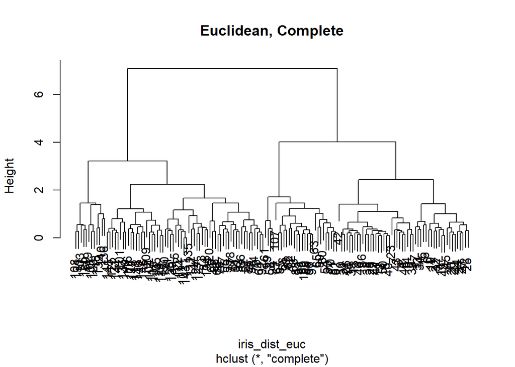

```r
iris_dist_euc <- dist(iris_Data, method = "euclidean")
iris_dist_manh <- dist(iris_Data, method = "manhattan") #Computing distance measures using euclidean and manhattan metrics.

tree_euc_comp <- hclust(iris_dist_euc, method = "complete")
tree_euc_avg <- hclust(iris_dist_euc, method = "average")
tree_manh_comp <- hclust(iris_dist_manh, method = "complete")
tree_manh_avg <- hclust(iris_dist_manh, method = "average") #For both euclidean and manhattan measures, we use a complete and average linkage type to plot a dendogram.

tree_ec_k2 <- cutree(tree_euc_comp, k = 2)
tree_ec_k3 <- cutree(tree_euc_comp, k = 3) #For the euclidean complete linkage tree, we draw two new trees cutting each into 2 groups and 3 groups, respectively.

plot(tree_euc_comp, main = "Euclidean, Complete")
```

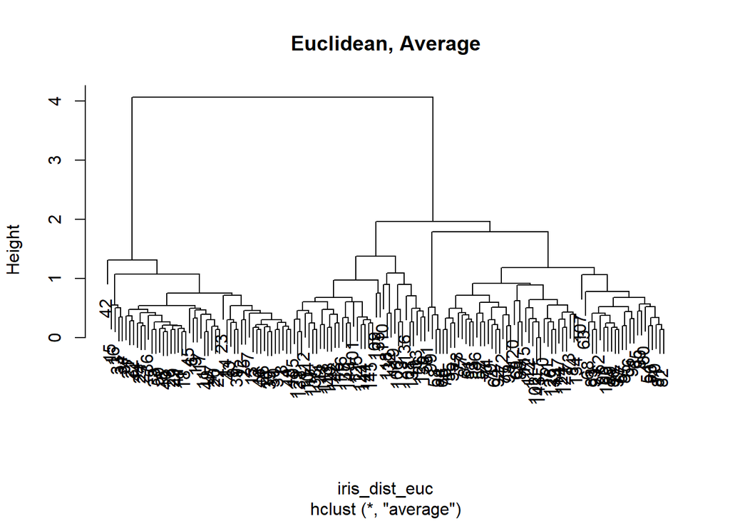

```r
plot(tree_euc_avg, main = "Euclidean, Average")
```

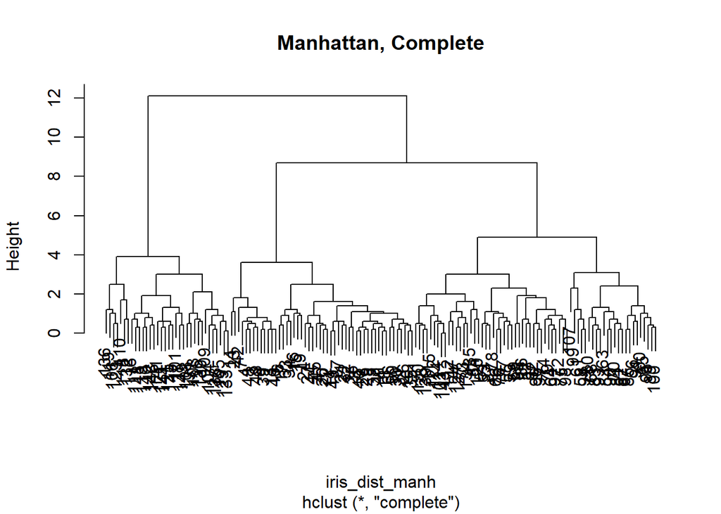

```r
plot(tree_manh_comp, main = "Manhattan, Complete")
```

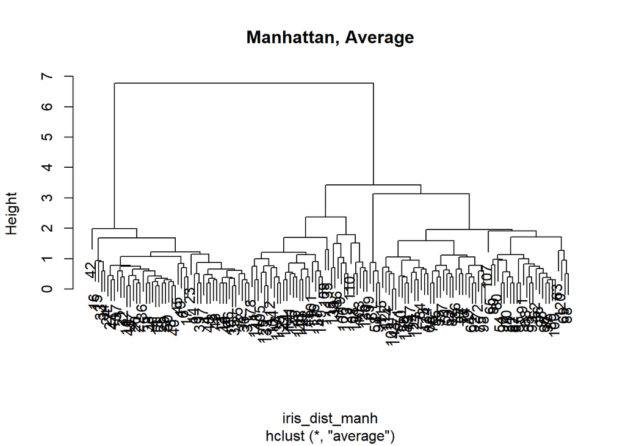

```r
plot(tree_manh_avg, main = "Manhattan, Average")
```

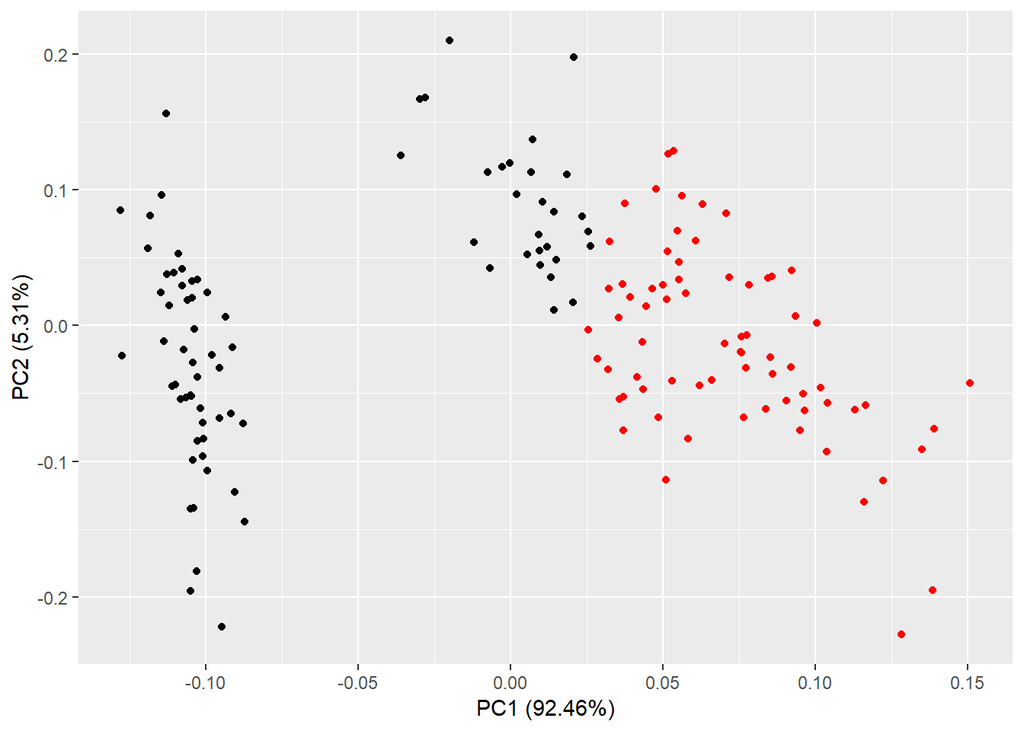

```r
autoplot(prcomp(iris_pca), col = tree_ec_k2)
```

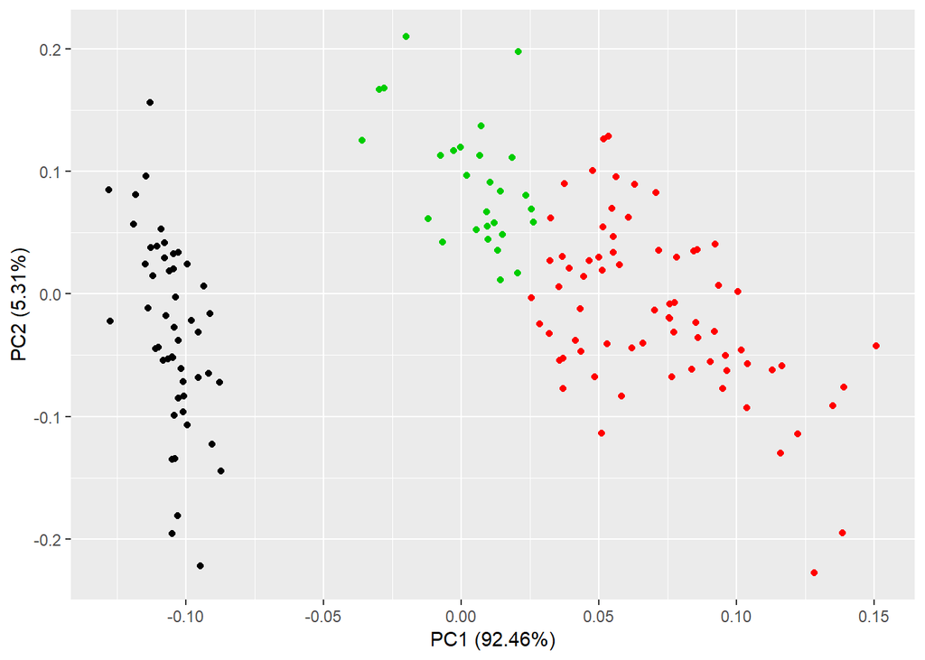

```r
autoplot(prcomp(iris_pca), col = tree_ec_k3)
```